# ML_project_TiU-7

## XGBoost

```python
model = XGBRegressor(objective='reg:squarederror', n_estimators=100, learning_rate=0.1)
model.fit(X_train_scaled, y_train)
y_pred = model.predict(X_val_scaled)
mse = mean_squared_error(y_val, y_pred)
r2 = r2_score(y_val, y_pred)
print('Mean Squared Error:', mse)
print('R^2 Score:', r2)
```

```
Mean Squared Error: 2296430810.1613545
R^2 Score: 0.8262964871041423
```

```python
xgb_model = XGBRegressor(objective='reg:squarederror', random_state=42)

# Define the parameter grid
param_grid = {
    'n_estimators': [50, 100, 200],         # Number of trees
    'max_depth': [3, 5, 7],                # Tree depth
    'learning_rate': [0.01, 0.1, 0.2],     # Step size shrinkage
    'min_child_weight': [1, 3, 5],         # Minimum child weight
    'gamma': [0, 0.1, 0.2],                # Minimum loss reduction
    'subsample': [0.8, 1.0],               # Fraction of samples per tree
}

# GridSearchCV
grid_search = GridSearchCV(
    estimator=xgb_model,
    param_grid=param_grid,
    scoring='neg_mean_squared_error',
    cv=3,
    verbose=1,
    n_jobs=-1
)

# Fit GridSearchCV
grid_search.fit(X_train_scaled, y_train)

# Best parameters and best model
best_params = grid_search.best_params_
best_model = grid_search.best_estimator_

# Print best parameters
print("Best Parameters:", best_params)

# Evaluate the best model
y_pred = best_model.predict(X_val_scaled)
mse = mean_squared_error(y_val, y_pred)
r2 = r2_score(y_val, y_pred)
print("Mean Squared Error (MSE):", mse)
print("R^2: ", r2)
```

```
Fitting 3 folds for each of 486 candidates, totalling 1458 fits
Best Parameters: {'gamma': 0, 'learning_rate': 0.1, 'max_depth': 7, 'min_child_weight': 1, 'n_estimators': 200, 'subsample': 0.8}
Mean Squared Error (MSE): 2131670624.1978767
R^2:  0.8387590542150669
```

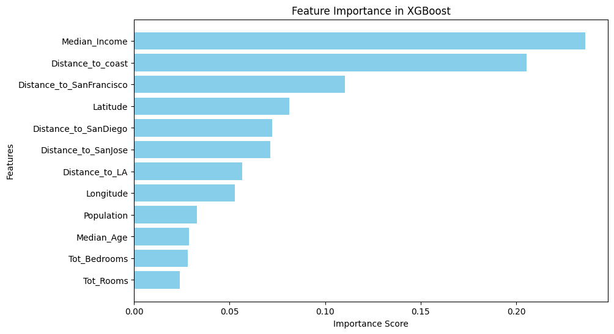

```python
importance =best_model.feature_importances_
feature_names = features_list

# Create a DataFrame for sorting
importance_df = pd.DataFrame({
    'Feature': feature_names,
    'Importance': importance
}).sort_values(by='Importance', ascending=False)

# Plot feature importance
plt.figure(figsize=(10, 6))
plt.barh(importance_df['Feature'], importance_df['Importance'], color='skyblue')
plt.xlabel('Importance Score')
plt.ylabel('Features')
plt.title('Feature Importance in XGBoost')
plt.gca().invert_yaxis()  # Invert y-axis for descending order
plt.show()
```

Here we see that the most important features are Median income, Distance to coast and Distances to cities.

At the same time, for this model, neighborhood properties are not that important.

So it means, that for XGBoost location of the neighborhood and it's is the most important information.

## Final model selection

Here now we are using our Test dataset.

We will use the best models we got from fine-tuning (i.e best variations with best hyperparameters) in the previous part and obtain new metric.

After that we can comment on that.

```python
#Linear model:

model=LinearRegression()

model.fit(X_train_poly, y_train)
y_pred = model.predict(X_test_poly)
mse = mean_squared_error(y_test, y_pred)
r2 = r2_score(y_test, y_pred)

print(f'Model MSE is {mse} and its R^2 is: {r2}')
```

```
Model MSE is 3406085003.0672407 and its R^2 is: 0.7323009144050747
```

```python
#Decision Trees:
model = DecisionTreeRegressor(
    max_depth=None,
    max_features=None,
    min_samples_leaf=4,
    min_samples_split=10,
    random_state=42
)

# Train the model
model.fit(X_train_scaled, y_train)

# Make predictions
y_pred = model.predict(X_test_scaled)

# Evaluate the model
mse = mean_squared_error(y_test, y_pred)
r2 = r2_score(y_test, y_pred)

print(f'Model MSE is {mse} and its R^2 is: {r2}')
```

```
Model MSE is 3453427134.9024177 and its R^2 is: 0.7285800896485057
```

```python
#XGBoost:

model=XGBRegressor(gamma=0,
    learning_rate=0.1,
    max_depth=7,
    min_child_weight=1,
    n_estimators=200,
    subsample=0.8,
    objective='reg:squarederror',  # Objective for regression
    random_state=42)

model.fit(X_train_scaled, y_train)

y_pred=model.predict(X_test_scaled)

mse = mean_squared_error(y_test, y_pred)
r2 = r2_score(y_test, y_pred)
mae=mean_absolute_error(y_test,y_pred)

print(f'Model MSE is {mse} and its R^2 is: {r2}')
print(f'Model MAE is {mae}')
```

```
Model MSE is 1981812201.238922 and its R^2 is: 0.84424072986588
Model MAE is 29009.33459690528
```

This results are leading to such conclusions:

1. As expected, XGBoost show really good results
2. Linear model with polynomial features is also quite accurate and is as accurate as Decision Trees.

Our final selection is biased as at the beginning it was told that XGBoost is the best performing model.

After fine-tuning all 3 models on the testing set we still get that XGBoost has the lowest MSE.

Possible way to improve models: to go deeper into models, choose more parameters and fine a way to lower MSE. However, after more than 100 runs of different models on different subsets of data with different parameters it seems that improvements will not lead to a much better performance. So the only way is to wait for a completely new models.

The most interesting insight we got is that when trying to predict the median house value of a neighborhood (so an average price of a house somewhere) is to look at the location and neighbors. And on the contrary, population / comfort level of houses (number of rooms or the age of the houses) are not that important.

And that is great indeed because it really supports the common view that in the US housing market is more dependent on the people who leave nearby and how prestigious is the neighborhood, rather than anything else.

At the end, our best model can make predictions with an $R^2$ of 0.84 which is somewhat accurate.

What is significant here is that MAE of our model on the test set is less than 30K$. So on average, our algorithm make mistake of 30 thousand US dollars.

However, mean price in this dataset is 206K4 , while it's standard deviation is 115k$. So our predictions there are somehow accurate and reliable.

So, using this model we can somehow accurately estimate a median housing price in any neighborhood in California and that is exactly what we wanted to do initially.

This model can be used by real estate agencies in the state for housing pricing process or for policymakers of the state of California for finding solutions to the current housing crisis.